# Bird activity in my backyard

## Introduction

This project explores bird activity recorded in my backyard using observations collected over time. The dataset includes the number of birds seen, the number of bird chirps - which I included as a proxy for bird activity as it can be hard to actually spot birds that are high in trees, weather conditions, type of bird, and timestamps for each observation.

I wanted to investigate two main questions:

- What times of day are birds most active?
- How does weather affect bird activity?

I decided to largely ignore the type of bird variable, as there were very few different types of birds, with the majority just being sparrows.

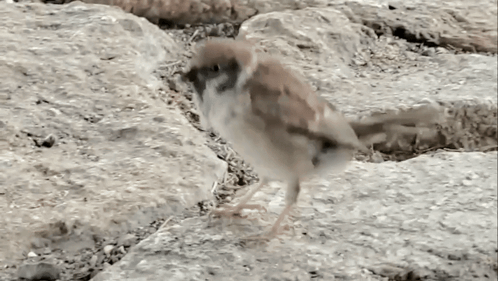

A sparrow bobbing up and down

## Bird Activity Throughout the Day

The first visualisation explores how bird chirping changes depending on the hour of the day.

The graph shows a clear spike in chirping activity at around 4pm, suggesting birds are most active during the late afternoon. Earlier morning hours and late evening periods show much lower average chirping levels. I believe that with more observations, this would start to resemble a normal distribution with a peak in the afternoon.

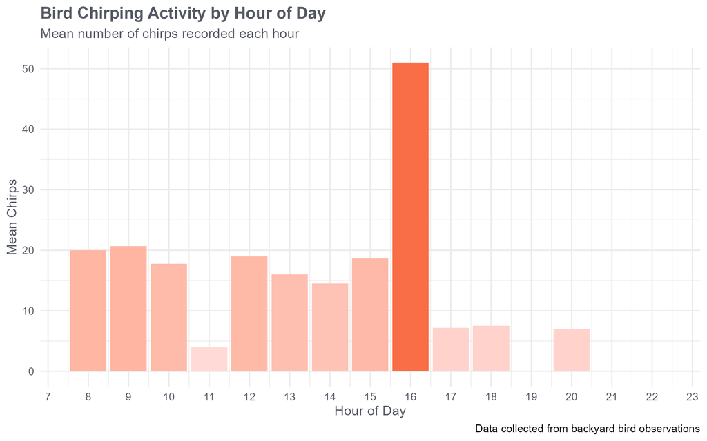

Bar plot showing average bird chirps by hour of day, with the highest bird activity occurring around 4pm.

## Weather Has a Strong Effect on Bird Activity

The next plot compares the average number of chirps heard under different weather conditions.

Sunny weather clearly leads to the highest bird activity, while rainy or cloudy weather has slightly less bird activity.

[figure not shown]

A bird sitting in a tree in the rain with an umbrella

This suggests weather conditions influence how active birds are in my backyard, although it is entirely possible I’m just worse at spotting birds in the rain as I’m eager to get back inside.

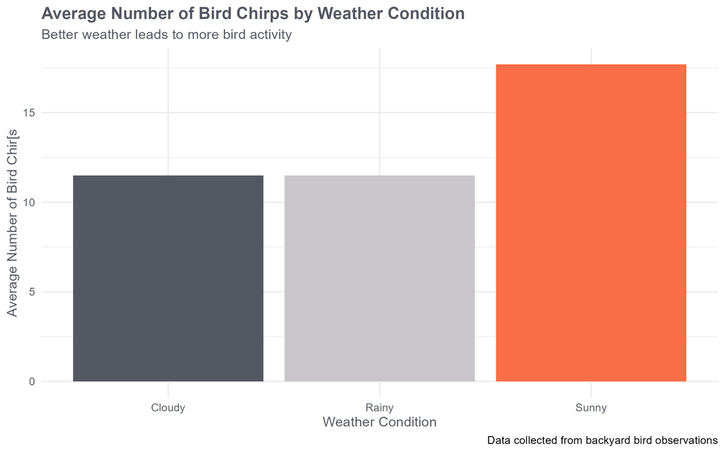

## Variation in Bird Chirps by Weather

While the previous graph showed averages, averages alone do not show how spread out the observations are. A boxplot provides more detail about variation and consistency in the data.

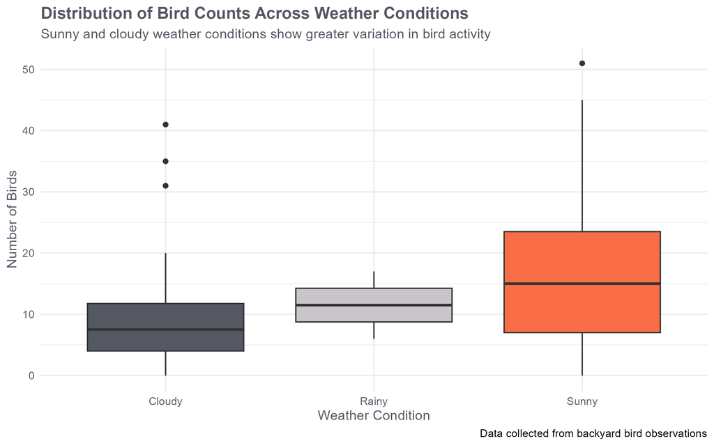

## Chirping as a Measure of Bird Activity

My final visualisation investigates whether bird chirping is a good proxy for overall bird activity.

The scatterplot shows a positive relationship between the number of birds observed and the number of chirps heard. As bird counts increase, chirping activity also generally increases.

The fitted regression line supports the idea that chirping is a useful indicator of bird presence and activity levels. This gives me reassurance that my use of bird chirps over just bird sightings was a reasonable idea to measure bird activity.

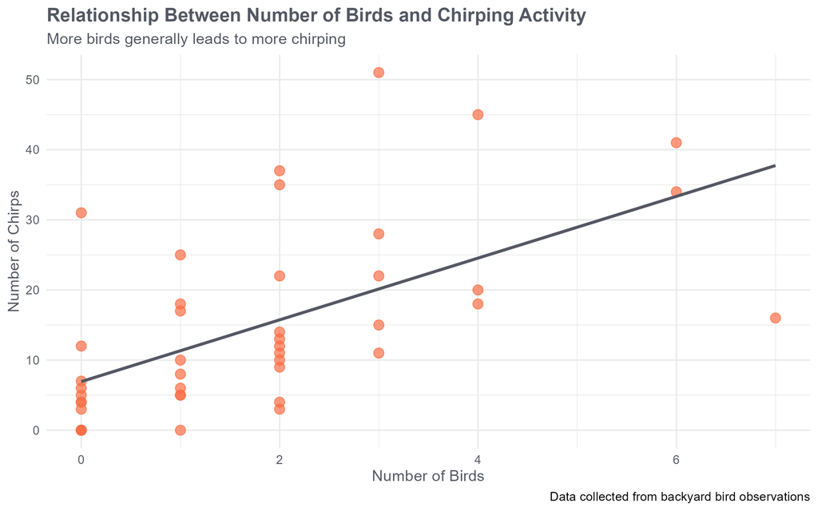

Scatterplot showing a positive relationship between number of birds observed and number of chirps heard. More birds generally leads to more chirping activity.

## Conclusion

Overall, the data suggests that both time of day and weather conditions strongly affect bird activity in my backyard.

Birds appear most active in the late afternoon, especially around 4pm, and activity is much higher during sunny weather compared with rainy or cloudy conditions. Additionally, chirping activity appears to be a reasonable proxy for overall bird activity, as larger bird counts generally correspond to more chirping.